# HW11

```python
import pandas as pd
import pandas_datareader as pdr
import numpy as np
```

## Use pandas datareader to download the year-to-date (from 12/31/21 to 11/4/22) SP500 index levels from Yahoo Finance, into a dataframe.

```python
dayofweek_map = { 0:'1) Mon'
                 ,1:'2) Tue'
                 ,2:'3) Wed'
                 ,3:'4) Thu'
                 ,4:'5) Fri'
                 ,5:'6) Sat'
                 ,6:'7) Sun'


                }
```

```python
df = pdr.data.DataReader(name="^GSPC", data_source="yahoo", start="2021-12-31", end="2022-11-4")
df = df.reset_index()

df['dayofweek'] = df['Date'].dt.dayofweek
df['dayofweek'] = df['dayofweek'].map(dayofweek_map)

df['%return'] = ((df['Close'] - df['Close'].shift(1))/df['Close'].shift(1))*100


print(df.shape)
df.head()
```

```
(214, 9)
```

|  | Date | High | Low | Open | Close | Volume | Adj Close | dayofweek | %return |
| --- | --- | --- | --- | --- | --- | --- | --- | --- | --- |
| 0 | 2021-12-31 | 4786.830078 | 4765.750000 | 4775.209961 | 4766.180176 | 2677820000 | 4766.180176 | 5) Fri | NaN |
| 1 | 2022-01-03 | 4796.640137 | 4758.169922 | 4778.140137 | 4796.560059 | 3831020000 | 4796.560059 | 1) Mon | 0.637405 |
| 2 | 2022-01-04 | 4818.620117 | 4774.270020 | 4804.509766 | 4793.540039 | 4683170000 | 4793.540039 | 2) Tue | -0.062962 |
| 3 | 2022-01-05 | 4797.700195 | 4699.439941 | 4787.990234 | 4700.580078 | 4887960000 | 4700.580078 | 3) Wed | -1.939276 |
| 4 | 2022-01-06 | 4725.009766 | 4671.259766 | 4693.390137 | 4696.049805 | 4295280000 | 4696.049805 | 4) Thu | -0.096377 |

## [b] Plot the year-to-date SP500 index

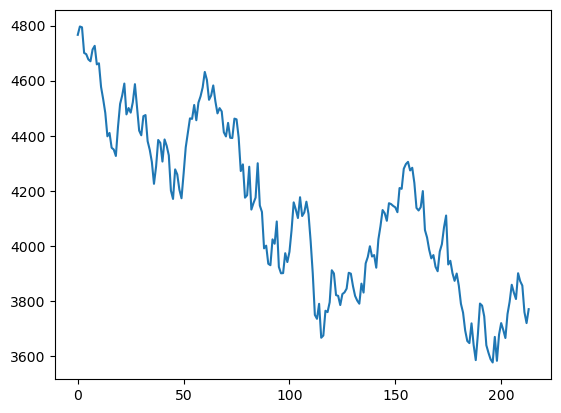

```python
lines = df['Close'].plot.line()
```

## [c] Let your code calculate the average return (in %) for each day of the week and plot the results.

```
dayofweek
1) Mon   -0.151598
2) Tue   -0.024379
3) Wed    0.096301
4) Thu   -0.291099
5) Fri   -0.128325
Name: %return, dtype: float64
```

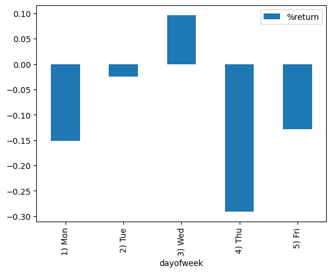

```python
print(df.groupby(['dayofweek'])['%return'].mean())
df.groupby(['dayofweek'])['%return'].mean().reset_index().plot.bar(x='dayofweek',y='%return')
```

## [d] Let your code count the number of up days and the number of down days for each day of the week and plot the results. An up day is one whose close is greater than or equal to the close of the previous trading day.

```python
df['upday']  = np.where(df['%return']>=0,1,0)
df['downday']  = np.where(df['%return']<0,1,0)
df.head()
```

|  | Date | High | Low | Open | Close | Volume | Adj Close | dayofweek | %return | upday | downday |
| --- | --- | --- | --- | --- | --- | --- | --- | --- | --- | --- | --- |
| 0 | 2021-12-31 | 4786.830078 | 4765.750000 | 4775.209961 | 4766.180176 | 2677820000 | 4766.180176 | 5) Fri | NaN | 0 | 0 |
| 1 | 2022-01-03 | 4796.640137 | 4758.169922 | 4778.140137 | 4796.560059 | 3831020000 | 4796.560059 | 1) Mon | 0.637405 | 1 | 0 |
| 2 | 2022-01-04 | 4818.620117 | 4774.270020 | 4804.509766 | 4793.540039 | 4683170000 | 4793.540039 | 2) Tue | -0.062962 | 0 | 1 |
| 3 | 2022-01-05 | 4797.700195 | 4699.439941 | 4787.990234 | 4700.580078 | 4887960000 | 4700.580078 | 3) Wed | -1.939276 | 0 | 1 |
| 4 | 2022-01-06 | 4725.009766 | 4671.259766 | 4693.390137 | 4696.049805 | 4295280000 | 4696.049805 | 4) Thu | -0.096377 | 0 | 1 |

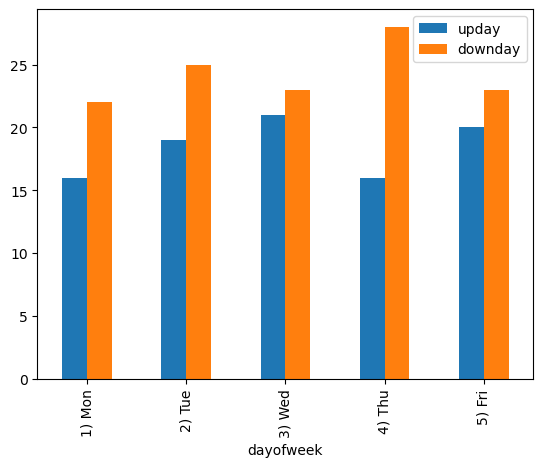

```python
df.groupby(['dayofweek'])[['upday','downday']].sum().reset_index().plot.bar(x='dayofweek')
```

## [e] Fit a simple logistic regression with day of the week as the only predictor to estimate the probability of SP500 going up or down given the day of the week. Let your code output the fitted coefficients (including the intercept) and report the log-likelihood achieved.

```python
import pandas as pd
import statsmodels.formula.api as smf

log_reg = smf.logit("upday ~ dayofweek", data=df).fit()
print(log_reg.summary())
```

```
Optimization terminated successfully.
         Current function value: 0.680199
         Iterations 4
                           Logit Regression Results
==============================================================================
Dep. Variable:                  upday   No. Observations:                  214
Model:                          Logit   Df Residuals:                      209
Method:                           MLE   Df Model:                            4
Date:                Sat, 12 Nov 2022   Pseudo R-squ.:                0.004521
Time:                        13:59:57   Log-Likelihood:                -145.56
converged:                       True   LL-Null:                       -146.22
Covariance Type:            nonrobust   LLR p-value:                    0.8576
=======================================================================================
                          coef    std err          z      P>|z|      [0.025      0.975]
---------------------------------------------------------------------------------------
Intercept              -0.3185      0.329     -0.969      0.332      -0.962       0.326
dayofweek[T.2) Tue]     0.0440      0.448      0.098      0.922      -0.834       0.922
dayofweek[T.3) Wed]     0.2275      0.446      0.510      0.610      -0.647       1.102
dayofweek[T.4) Thu]    -0.2412      0.454     -0.531      0.595      -1.131       0.649
dayofweek[T.5) Fri]     0.1361      0.447      0.305      0.761      -0.740       1.012
=======================================================================================
```

## [f] Let your code report the predicted probability of SP500 going up or down for each day of the week.

```python
df['y_pred_of_upday'] = log_reg.predict()
df.head()
```

|  | Date | High | Low | Open | Close | Volume | Adj Close | dayofweek | %return | upday | downday | y_pred_of_upday |
| --- | --- | --- | --- | --- | --- | --- | --- | --- | --- | --- | --- | --- |
| 0 | 2021-12-31 | 4786.830078 | 4765.750000 | 4775.209961 | 4766.180176 | 2677820000 | 4766.180176 | 5) Fri | NaN | 0 | 0 | 0.454545 |
| 1 | 2022-01-03 | 4796.640137 | 4758.169922 | 4778.140137 | 4796.560059 | 3831020000 | 4796.560059 | 1) Mon | 0.637405 | 1 | 0 | 0.421053 |
| 2 | 2022-01-04 | 4818.620117 | 4774.270020 | 4804.509766 | 4793.540039 | 4683170000 | 4793.540039 | 2) Tue | -0.062962 | 0 | 1 | 0.431818 |
| 3 | 2022-01-05 | 4797.700195 | 4699.439941 | 4787.990234 | 4700.580078 | 4887960000 | 4700.580078 | 3) Wed | -1.939276 | 0 | 1 | 0.477273 |
| 4 | 2022-01-06 | 4725.009766 | 4671.259766 | 4693.390137 | 4696.049805 | 4295280000 | 4696.049805 | 4) Thu | -0.096377 | 0 | 1 | 0.363636 |

```python
result = df[['dayofweek','y_pred_of_upday']].drop_duplicates().copy()
result = result.rename(columns={'y_pred_of_upday':'Proba_Up'})
result['Proba_down'] = 1 - result['Proba_Up']
result = result.sort_values(by='dayofweek')
result.head()
```

|  | dayofweek | Proba_Up | Proba_down |
| --- | --- | --- | --- |
| 1 | 1) Mon | 0.421053 | 0.578947 |
| 2 | 2) Tue | 0.431818 | 0.568182 |
| 3 | 3) Wed | 0.477273 | 0.522727 |
| 4 | 4) Thu | 0.363636 | 0.636364 |
| 0 | 5) Fri | 0.454545 | 0.545455 |